# Course quizzes

# 1 Week 1

## Function summary notes

d-p-q-r family of functions

| RV | Function(arguments) | Outcome |
| --- | --- | --- |
| Bernoulli | `rbern(n,prob)` | generate random data |
|  | `dbern(x,prob)` | PMF: *probability* of outcome x |
|  | `pbern(q,prob)` | CMF: cumulative PMF of <=q |
| Binomial | `rbinom(n, size, prob)` | generate random data with n = of successes |
|  | `dbinom(q,size,prob)` | PMF: *probability* of outcome x |
|  | `pbinom(q,size,prob)` | CMF: cumulative PMF of <=q |
|  | `qbinom(p,prob,size)` | inverse CMF: cumulative PMF of >=x |
| normal | `rnorm(n,mean,sd)` | generate random data |
|  | `dnorm(x,mean,sd)` | PDF: *density* of outcome x |
|  | `pnorm(q,mean,sd)` | CDF: cumulative PDF of <=q |
|  | `pnorm(q,mean,sd,` `lower.tail=F)` | inverse CDF: cumulative PDF of >=q |
|  | `qnorm(p,prob,size)` | Compute quantiles corresponding to probabilities |

## 1.1 Quiz: Binomial distribution

Q1: Consider participating in a lottery ten times. Each time the probability of winning a prize is 0.10. What is the probability of winning exactly 5 times?

```r
# use dbinom to compute PMF
round(
  dbinom(5, # produce probs for 5 successes
       size = 10, # out of 10 tries/trials
       prob = .1 # with a prob of success on each trial = .1
       ),
3)
```

```
## [1] 0.001
```

Q2: Consider lending 10 books from a library. The probability of getting a damaged book is 0.15. Compute the cumulative probability of having 2 or fewer damaged books rounded to three digits.

```r
# use pbinom to compute CMF
round(
  pbinom(2, # successes
    size = 10, # out of 10
    prob = .15 # with prob of .15

  ),
3)
```

```
## [1] 0.82
```

## 1.2 Quiz: Normal distribution

Q1: Given a standard normal distribution, what is the probability of getting a value lower than -3?

```r
pnorm(-3)
```

```
## [1] 0.001349898
```

Q2: Given a standard normal distribution, what is the probability of getting a value higher than -3?

```r
pnorm(-3, lower.tail=F)
```

```
## [1] 0.9986501
```

## 1.3 Quiz: Bivariate distribution

```r
pxy41 <- .096
py1 <- sum(.031,.053,.086,.096,.147,.153,.142)

px4y1 <- pxy41/py1; round(px4y1,3)
```

```
## [1] 0.136
```

And the exercise from Slide 9:

```r
# first compute the probabilities of y=0 and y=1
py0 <- sum(.018,.023,.04,.043,.063,.049,.055)
py1 <- sum(.031,.053,.086,.096,.147,.153,.142)

## now compute probabilities of x1:7 given y = 0
px1y0 <- .018/py0
px2y0 <- .023/py0
px3y0 <- .04/py0
px4y0 <- .043/py0
px5y0 <- .063/py0
px6y0 <- .049/py0
px7y0 <- .055/py0
## sum should equal 1
pxy0 <- sum(px1y0,px2y0,px3y0,px4y0,px5y0,px6y0,px7y0)

## now compute probabilities of x1:7 given y = 1
px1y1 <- .031/py1
px2y1 <- .053/py1
px3y1 <- .086/py1
px4y1 <- .096/py1
px5y1 <- .147/py1
px6y1 <- .153/py1
px7y1 <- .142/py1
# sum should equal 1
pxy1 <- sum(px1y1,px2y1,px3y1,px4y1,px5y1,px6y1,px7y1)

px17y0 <- c(px1y0,px2y0,px3y0,px4y0,px5y0,px6y0,px7y0, pxy0)
px17y1 <- c(px1y1,px2y1,px3y1,px4y1,px5y1,px6y1,px7y1, pxy1)

# create data frame for table
px17y10 <- as.data.frame(rbind(px17y0,px17y1))
```

```r
# print table
knitr::kable(px17y10,
             digits = 3,
             col.names =
              c("x=1","x=2","x=3","x=4",
                "x=5","x=6","x=7","sum"),
             # row.names =
             #   c("P(x=1:7|y=0)", "P(x=1:7|y=1)")
             ) %>%
  kable_styling()
```

|  | x=1 | x=2 | x=3 | x=4 | x=5 | x=6 | x=7 | sum |
| --- | --- | --- | --- | --- | --- | --- | --- | --- |
| px17y0 | 0.062 | 0.079 | 0.137 | 0.148 | 0.216 | 0.168 | 0.189 | 1 |
| px17y1 | 0.044 | 0.075 | 0.121 | 0.136 | 0.208 | 0.216 | 0.201 | 1 |

## 1.4 Self-test: week 1

### Question 1 (1.0 Pts)

Compute the probability of obtaining a value less than or equal to 5 in a normal distribution with mean 3 and standard deviation 1.

```r
round(pnorm(q = 5,
      mean = 3,
      sd = 1),
      3)
```

```
## [1] 0.977
```

### Question 2 (1.0 Pts)

Compute the probability of obtaining a value less than or equal to 5 in a normal distribution with mean 3 and standard deviation 3.

```r
round(pnorm(q = 5,
      mean = 3,
      sd = 3),
      3)
```

```
## [1] 0.748
```

### Question 3 (1.0 Pts)

Compute the probability of obtaining a value more than 5 in a normal distribution with mean 3 and standard deviation 1.

```r
round(pnorm(q = 5,
      mean = 3,
      sd = 1,
      lower.tail = F),
      3)
```

```
## [1] 0.023
```

### Question 4 (1.0 Pts)

Compute the probability of obtaining a value more than or equal to 5 in a normal distribution with mean 4 and standard deviation 3.

```r
round(pnorm(q = 5,
      mean = 4,
      sd = 3,
      lower.tail = F),
      3)
```

```
## [1] 0.369
```

### Question 5 (1.0 Pts)

Compute the probability of obtaining a value between 2 and 5 in a normal distribution with mean 3 and standard deviation 1.

```r
round(pnorm(5,3,1)-pnorm(2,3,1),
      3)
```

```
## [1] 0.819
```

### Question 6 (1.0 Pts)

Compute the probability of obtaining a value between 1 and 1.5 in a normal distribution with mean 3 and standard deviation 1.

```r
round(pnorm(1.5,3,1) -
        pnorm(1,3,1),
      3)
```

```
## [1] 0.044
```

### Question 7 (1.0 Pts)

Compute the probability of obtaining a value between 1 and 1.5 in a standard normal distribution.

```r
round(pnorm(1.5,0,1) -
        pnorm(1,0,1),
      3)
```

```
## [1] 0.092
```

### Question 8 (1.0 Pts)

Compute the probability of obtaining 4 or fewer successes in 15 trials following a binomial distribution with probability of success being 0.5.

```r
round(
  pbinom(4,15,.5),
  3)
```

```
## [1] 0.059
```

### Question 9 (1.0 Pts)

Compute the probability of obtaining 3, 4, or 5 successes in 15 trials following a binomial distribution with probability of success being 0.5.

```r
round(
  sum(
    dbinom(3:5,15,.5)
    ),
  3)
```

```
## [1] 0.147
```

### Question 10 (1.0 Pts)

Compute the probability of obtaining 2, 3, 4, or 5 successes in 25 trials following a binomial distribution with probability of success being 0.25.

```r
round(
  sum(
    dbinom(2:5,25,.25)
    ),
  3)
```

```
## [1] 0.371
```

### Question 11 (1.0 Pts)

Consider participating in a lottery ten times. Each time the probability of winning a prize is 0.05. Compute the cumulative probability of winning 2 times or less rounded to three digits.

```r
round(
  pbinom(q = 2,
         size = 10,
         prob = .05),
  3
)
```

```
## [1] 0.988
```

```r
# this is a pretty high prob because there are large chances of winning 0 times
```

### Question 12 (1.0 Pts)

Compute the value k such that the probability of obtaining k or fewer successes in 15 binomial samples with probability of success being 0.5 is 0.75.

```r
round(
  qbinom(.75,
         size = 15,
         prob = .5),
      3)
```

```
## [1] 9
```

### Question 13 (1.0 Pts)

Compute the value k such that the probability of obtaining k or fewer successes in 55 binomial samples with probability of success being 0.75 is 0.25.

```r
round(
  qbinom(.25,
         size = 55,
         prob = .75),
      3)
```

```
## [1] 39
```

### Question 14 (1.0 Pts)

What is the quantile q in a standard normal distribution, such that the probability of observing that value q or a value less than q is 0.25?

```r
round(
  qnorm(.25,
         mean = 0,
         sd = 1),
      3)
```

```
## [1] -0.674
```

### Question 15 (1.0 Pts)

Consider a normal distribution with mean 1 and standard deviation 1. Compute the boundary such that the area (the probability) to the left of it is 0.10.

```r
round(
  qnorm(p = .1,
         mean = 1,
         sd = 1),
      3)
```

```
## [1] -0.282
```

### Question 16 (1.0 Pts)

What is the probability of obtaining 6 successes in 18 trials following the binomial distribution with probability of success being 0.65?

```r
round(
  dbinom(x = 6,
         size = 18,
         p = .65),
      3)
```

```
## [1] 0.005
```

### Question 17 (1.0 Pts)

What is the probability of obtaining 17 successes in 18 trials following the binomial distribution with probability of success being 0.75?

```r
round(
  dbinom(x = 17,
         size = 18,
         p = .75),
      3)
```

```
## [1] 0.034
```

### Question 18 (1.0 Pts)

What is the probability of obtaining 6 successes in 60 trials following the binomial distribution with probability of success being 0.1?

```r
round(
  dbinom(x = 6,
         size = 60,
         p = .1),
      3)
```

```
## [1] 0.169
```

### Question 19 (1.0 Pts)

Given a normal distribution with mean 650 and standard deviation 125, there exist two quantiles, the lower quantile q1 and the upper quantile q2, that are equidistant from the mean, such that the area under the curve between q1 and q2 is 80%. Find q1 and q2.

```r
round(
  qnorm(p = c(.1,.9),
         mean = 650,
         sd = 125),
      3)
```

```
## [1] 489.806 810.194
```

```r
# alternative
q1 <- qnorm(p = .1, 650,125)
q2 <- qnorm(p = .1, 650,125, lower.tail=F)
```

# 2 Week 2

## Question 1 (1.0 Pts)

We ask a subject 10 yes/no questions, and the subject returns 0 correct answers. We assume a binomial likelihood function for this data. We also assume a Beta(1, 1) prior on the parameter θ, which represents the probability of success. Write down the posterior distribution of the θ parameter.

```r
# prior Beta(a,b)
a <- 1
b <- 1

# observed data
n <- 10 # trials
k <- 0 # successes

# posterior Beta equation (from section 2.7 in the book)
# posterior beta =
post_a <- a+k; post_a
```

```
## [1] 1
```

```r
post_b <- b + n - k; post_b
```

```
## [1] 11
```

The answer is *Beta(*1,11*)*.

## Question 2 (1 Pt)

Suppose you have n independent and identically distributed data points from the Geometric distribution, which has the likelihood function:

$$\begin{equation}
f(x|\theta)=\theta(1-\theta)^{\sum_{i=1}^n x_i}
\end{equation}$$

where the data points $x$ can have values 0, 1, 2, 3, … Let the prior on $\theta$ be $Beta (a, b)$, a beta distribution with parameters a, b. The posterior distribution is a beta distribution with parameters $a*$ and $b*$. Determine these parameters in terms of a, b and the sum of all x’s.

Solution:

The prior is Beta(a,b).

The posterior likelihood is: $\theta(1 - \theta)^{\sum^{n}_{i=1^{x_{i}-1}}}$

The posterior up to proportionality is:

$[\theta^{a-1}(1 - \theta)^{b-1}][\theta(1 - \theta)^{\sum^{n}_{i=1^{x_{i}-1}}}]$

Re-arranging terms, where we add the exponents from either side (and where there is no exponent, we add ‘+1’ because no exponent = ‘to the power of 1’):

$\theta^{a + 1 - 1}(1 - \theta)^{b + \sum^{n}_{i=1^{x_{i}-1}}}$

If the posterior is a Beta distribution then its parameters are: $Beta(a + 1, b + \sum^{n}_{i=1^{x_{i}-1}})$. Thus:

$a* = a +1$

$b* = b + \sum^{n}_{i=1^{x_{i}-1}}$

# 3 Week 3

## Question 1 (1 Pt.)

Fit the model `fit_press` with just a few iterations, say 50 iterations (set warmup to the default of 25, and use four chains). Does the model converge (yes/no)?

```r
# load data from bcogsci package
data("df_spacebar")

# run fit_press with 50 iterations
fit_press <- brm(rt ~ 1,
  data = df_spacebar,
  family = gaussian(),
  prior = c(
    prior(uniform(0, 60000), class = Intercept, lb = 0, ub = 60000),
    prior(uniform(0, 2000), class = sigma, lb = 0, ub = 2000)
  ),
  chains = 4,
  iter = 50,
  warmup = 25
  ## uncomment for prior predictive:
  ## sample_prior = "only",
  ## uncomment when dealing with divergent transitions
  ## control = list(adapt_delta = .9)
); fit_press
```

[output not shown]

```
##  Family: gaussian
##   Links: mu = identity; sigma = identity
## Formula: rt ~ 1
##    Data: df_spacebar (Number of observations: 361)
##   Draws: 4 chains, each with iter = 50; warmup = 25; thin = 1;
##          total post-warmup draws = 100
##
## Population-Level Effects:
##           Estimate Est.Error l-95% CI u-95% CI Rhat Bulk_ESS Tail_ESS
## Intercept   190.88     36.91   139.88   268.40 2.44        7       12
##
## Family Specific Parameters:
##       Estimate Est.Error l-95% CI u-95% CI Rhat Bulk_ESS Tail_ESS
## sigma   354.19    572.19    24.79  1574.63 3.69        7       14
##
## Draws were sampled using sampling(NUTS). For each parameter, Bulk_ESS
## and Tail_ESS are effective sample size measures, and Rhat is the potential
## scale reduction factor on split chains (at convergence, Rhat = 1).
```

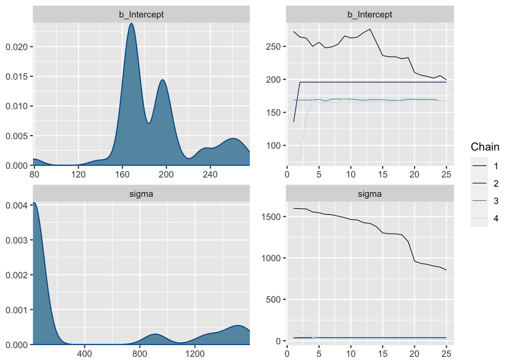

```r
plot(fit_press)
```

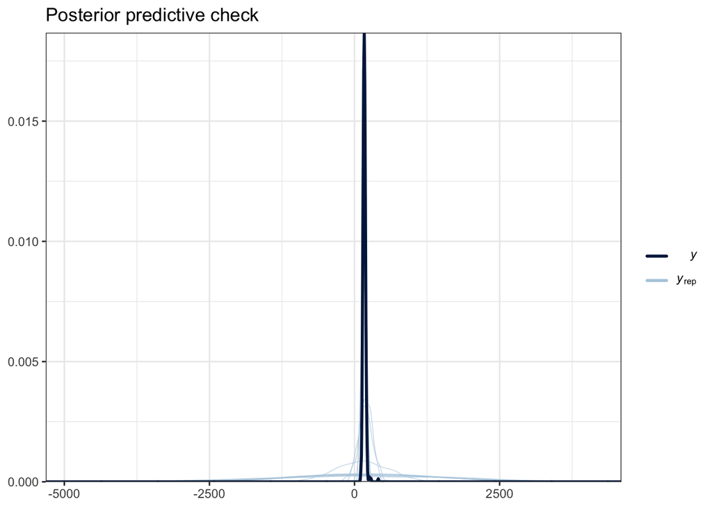

```r
# density plots
pp_check(fit_press, # model
         ndraws = 25, # n of predicted data sets
         type = "dens_overlay" # plot type
         ) + theme_bw() +
  labs(title = "Posterior predictive check")
```

**My answer:** no, it did not converge:

## Question 2 (1 Pt.)

Let’s revisit the button-pressing example with different priors. Can you come up with very informative priors that influence the posterior in a noticeable way (use normal distributions for priors, not uniform priors)?

```r
# run fit_press with informative priors
fit_press_inf <- brm(rt ~ 1,
  data = df_spacebar,
  family = gaussian(),
  prior = c(
    prior(normal(1500, 10), class = Intercept),
    prior(normal(50, 2), class = sigma)
  ),
  chains = 4,
  iter = 2000,
  warmup = 1000
  ## uncomment for prior predictive:
  ## sample_prior = "only",
  ## uncomment when dealing with divergent transitions
  ## control = list(adapt_delta = .9)
); fit_press_inf
```

[output not shown]

```
##  Family: gaussian
##   Links: mu = identity; sigma = identity
## Formula: rt ~ 1
##    Data: df_spacebar (Number of observations: 361)
##   Draws: 4 chains, each with iter = 2000; warmup = 1000; thin = 1;
##          total post-warmup draws = 4000
##
## Population-Level Effects:
##           Estimate Est.Error l-95% CI u-95% CI Rhat Bulk_ESS Tail_ESS
## Intercept   688.13     10.03   667.96   707.70 1.00     1187     1160
##
## Family Specific Parameters:
##       Estimate Est.Error l-95% CI u-95% CI Rhat Bulk_ESS Tail_ESS
## sigma   151.96      1.78   148.41   155.50 1.00     1237     1335
##
## Draws were sampled using sampling(NUTS). For each parameter, Bulk_ESS
## and Tail_ESS are effective sample size measures, and Rhat is the potential
## scale reduction factor on split chains (at convergence, Rhat = 1).
```

```r
# run fit_press with informative priors
prior_fit_press_inf <- brm(rt ~ 1,
  data = df_spacebar,
  family = gaussian(),
  prior = c(
    prior(normal(1500, 10), class = Intercept),
    prior(normal(50, 2), class = sigma)
  ),
  sample_prior = "only",
  chains = 4,
  iter = 2000,
  warmup = 1000
  ## uncomment for prior predictive:
  ## sample_prior = "only",
  ## uncomment when dealing with divergent transitions
  ## control = list(adapt_delta = .9)
); prior_fit_press_inf
```

[output not shown]

```
##  Family: gaussian
##   Links: mu = identity; sigma = identity
## Formula: rt ~ 1
##    Data: df_spacebar (Number of observations: 361)
##   Draws: 4 chains, each with iter = 2000; warmup = 1000; thin = 1;
##          total post-warmup draws = 4000
##
## Population-Level Effects:
##           Estimate Est.Error l-95% CI u-95% CI Rhat Bulk_ESS Tail_ESS
## Intercept  1500.31      9.95  1480.27  1519.37 1.00     3185     2670
##
## Family Specific Parameters:
##       Estimate Est.Error l-95% CI u-95% CI Rhat Bulk_ESS Tail_ESS
## sigma    50.04      1.98    46.14    53.83 1.00     3357     2499
##
## Draws were sampled using sampling(NUTS). For each parameter, Bulk_ESS
## and Tail_ESS are effective sample size measures, and Rhat is the potential
## scale reduction factor on split chains (at convergence, Rhat = 1).
```

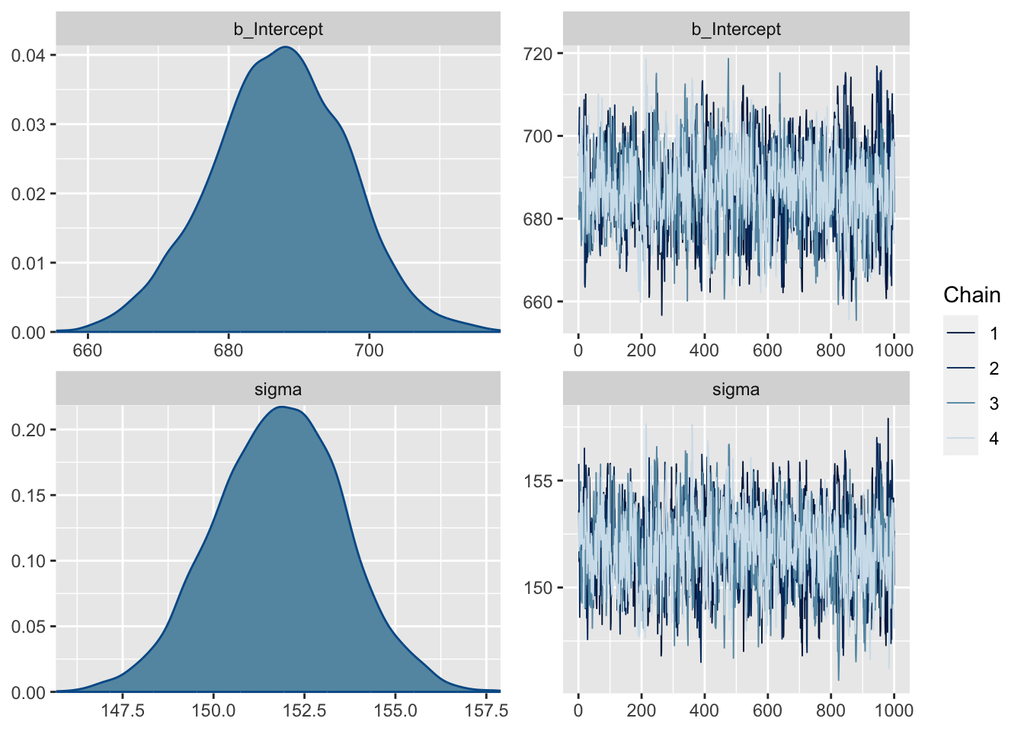

```r
plot(fit_press_inf)
```

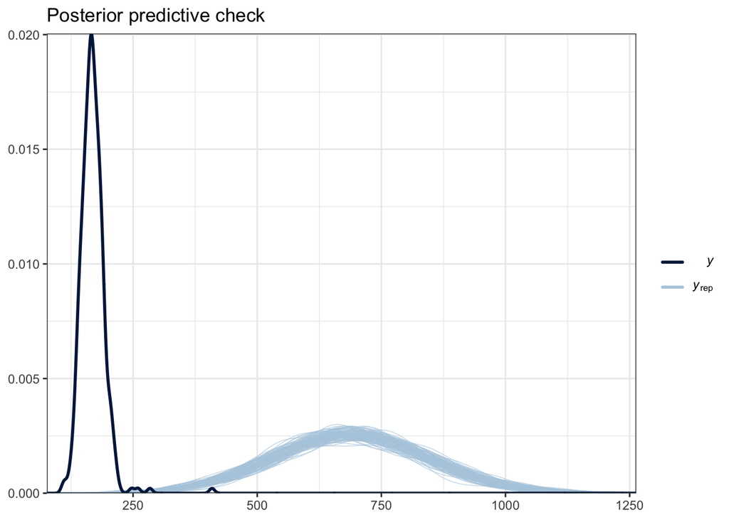

```r
# density plots
pp_check(fit_press_inf, # model
         ndraws = 100, # n of predicted data sets
         type = "dens_overlay" # plot type
         ) + theme_bw() +
  labs(title = "Posterior predictive check")
```

Generate and plot prior predictive distributions based on this prior and plot them. (See Plot A)

Generate posterior predictive distributions based on this prior and plot them. (See Plot B)

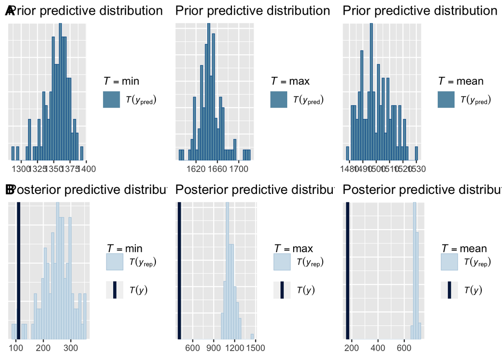

```r
ggpubr::ggarrange(
## Plot prior predictive distribution of statistical summaries:
pp_check(prior_fit_press_inf, ndraws = 100, type = "stat", stat = "min",
         prefix = "ppd") +
  labs(title = "Prior predictive distribution"),
## Plot prior predictive distribution of statistical summaries:
pp_check(prior_fit_press_inf, ndraws = 100, type = "stat", stat = "max",
         prefix = "ppd") +
  labs(title = "Prior predictive distribution"),
## Plot prior predictive distribution of statistical summaries:
pp_check(prior_fit_press_inf, ndraws = 100, type = "stat", stat = "mean",
         prefix = "ppd") +
  labs(title = "Prior predictive distribution"),
## Plot posterior predictive distribution of statistical summaries:
pp_check(fit_press_inf, ndraws = 100, type = "stat", stat = "min") +
  labs(title = "Posterior predictive distribution"),
## Plot posterior predictive distribution of statistical summaries:
pp_check(fit_press_inf, ndraws = 100, type = "stat", stat = "max") +
  labs(title = "Posterior predictive distribution"),
## Plot posterior predictive distribution of statistical summaries:
pp_check(fit_press_inf, ndraws = 100, type = "stat", stat = "mean") +
  labs(title = "Posterior predictive distribution"),
nrow = 2, ncol=3, labels = c("A","", "", "B")
)
```

**My comments:** model converged (fat hairy caterpillar), but the model is *not* a good fit (posterior predictive check density plots). This was our goal: a model overly influenced by the priors, which were much higher and tighter than is realistic for reaction time data.

## Question 3 (1 Pt.)

Let’s revisit the `fit_press_ln` model. Change the prior of $\sigma$ so that it is a log-normal distribution with location ($\mu$) of −2 and scale ($\sigma$) of .5. What does such a prior imply about your belief regarding button-pressing times in milliseconds?

**My comment:** it implies that we believe the mean will be $\frac{\mu + \sigma^2}{2}$ = $\frac{-2 + 0.5^2}{2}$:

```r
mu <- -2
sigma = .5

# the mean is
exp((mu + sigma^2)/2)
```

```
## [1] 0.416862
```

```r
# and the median is
exp(mu)
```

```
## [1] 0.1353353
```

```r
fit_press_ln <- brm(rt ~ 1,
  data = df_spacebar,
  family = lognormal(),
  prior = c(
    prior(normal(6, 1.5), class = Intercept),
    prior(normal(-2, .5), class = sigma)
  )
); fit_press_ln
```

[output not shown]

```
##  Family: lognormal
##   Links: mu = identity; sigma = identity
## Formula: rt ~ 1
##    Data: df_spacebar (Number of observations: 361)
##   Draws: 4 chains, each with iter = 2000; warmup = 1000; thin = 1;
##          total post-warmup draws = 4000
##
## Population-Level Effects:
##           Estimate Est.Error l-95% CI u-95% CI Rhat Bulk_ESS Tail_ESS
## Intercept     5.12      0.01     5.10     5.13 1.00     3842     2709
##
## Family Specific Parameters:
##       Estimate Est.Error l-95% CI u-95% CI Rhat Bulk_ESS Tail_ESS
## sigma     0.13      0.01     0.13     0.15 1.00     3002     2415
##
## Draws were sampled using sampling(NUTS). For each parameter, Bulk_ESS
## and Tail_ESS are effective sample size measures, and Rhat is the potential
## scale reduction factor on split chains (at convergence, Rhat = 1).
```

```r
prior_fit_press_ln <- brm(rt ~ 1,
  data = df_spacebar,
  family = lognormal(),
  prior = c(
    prior(normal(6, 1.5), class = Intercept),
    prior(normal(-2, .5), class = sigma)
  ),
  sample_prior = "only",
); prior_fit_press_ln
```

[output not shown]

```
##  Family: lognormal
##   Links: mu = identity; sigma = identity
## Formula: rt ~ 1
##    Data: df_spacebar (Number of observations: 361)
##   Draws: 4 chains, each with iter = 2000; warmup = 1000; thin = 1;
##          total post-warmup draws = 4000
##
## Population-Level Effects:
##           Estimate Est.Error l-95% CI u-95% CI Rhat Bulk_ESS Tail_ESS
## Intercept     6.01      1.50     3.09     9.08 1.00     1468     1869
##
## Family Specific Parameters:
##       Estimate Est.Error l-95% CI u-95% CI Rhat Bulk_ESS Tail_ESS
## sigma     0.11      0.11     0.00     0.39 1.00     1791     1561
##
## Draws were sampled using sampling(NUTS). For each parameter, Bulk_ESS
## and Tail_ESS are effective sample size measures, and Rhat is the potential
## scale reduction factor on split chains (at convergence, Rhat = 1).
```

Is it a good prior?

```r
estimate_ms <- exp(as_draws_df(fit_press_ln)$b_Intercept)

c(mean = mean(estimate_ms), sd = sd(estimate_ms), quantile(estimate_ms, probs = c(.025, .975)))
```

```
##       mean         sd       2.5%      97.5%
## 167.056707   1.218436 164.709728 169.385932
```

**My comment:** yes it’s pretty good I’d say (similar peaks and distribution of majority of observations)

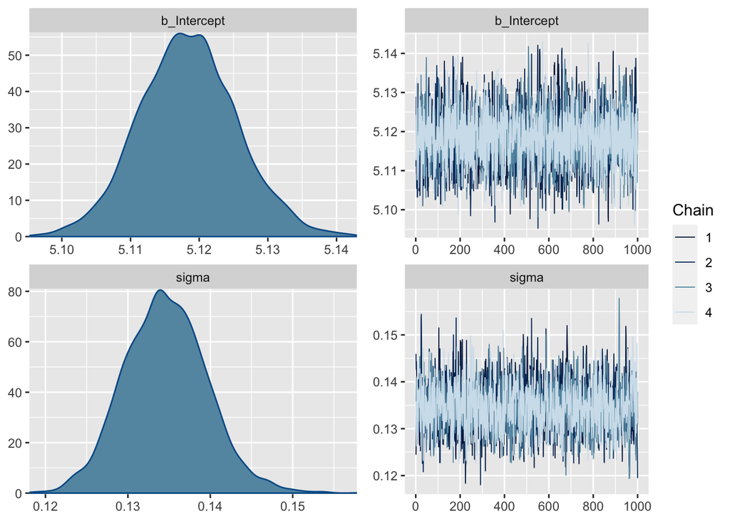

```r
plot(fit_press_ln)
```

[figure not shown]

```r
ggpubr::ggarrange(
# prior density plot
pp_check(fit_press_ln, # model
         ndraws = 100, # n of predicted data sets
         prefix = "ppd",
         type = "dens_overlay" # plot type
         ) +
  xlim(NA,400) +
  theme_bw() +
  labs(title = "Prior predictive check"),

# posterior density plots
pp_check(fit_press_ln, # model
         ndraws = 100, # n of predicted data sets
         type = "dens_overlay" # plot type
         ) + theme_bw() +
  labs(title = "Posterior predictive check"),
nrow = 2,
labels = c("A","B")
)
```

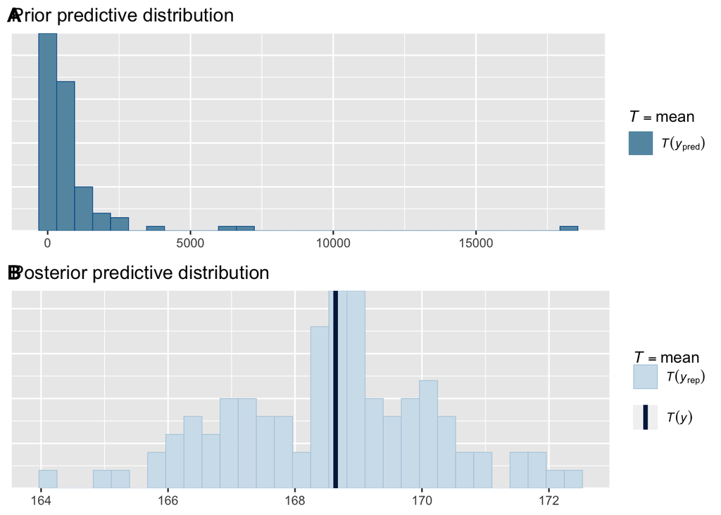

```r
ggpubr::ggarrange(
## Plot prior predictive distribution of statistical summaries:
pp_check(prior_fit_press_ln, ndraws = 100, type = "stat", stat = "mean",
         prefix = "ppd") +
  labs(title = "Prior predictive distribution"),

## Plot posterior predictive distribution of statistical summaries:
pp_check(fit_press_ln, ndraws = 100, type = "stat", stat = "mean") +
  labs(title = "Posterior predictive distribution"),
nrow = 2, labels = c("A","B")
)
```

[figure not shown]

```r
p1 <- pp_check(prior_fit_press_ln, type = "stat", stat = "mean", prefix = "ppd") +
  coord_cartesian(xlim = c(0.001, 300000)) +
  scale_x_continuous("Response times [ms]",
    trans = "log",
    breaks = c(0.001, 1, 100, 1000, 10000, 100000),
    labels = c(
      "0.001", "1", "100", "1000", "10000",
      "100000"
    )
  ) +
  ggtitle("Prior predictive distribution of means")
p2 <- pp_check(fit_press_ln, type = "stat", stat = "min", prefix = "ppd") +
  coord_cartesian(xlim = c(0.001, 300000)) +
  scale_x_continuous("Response times [ms]",
    trans = "log",
    breaks = c(0.001, 1, 100, 1000, 10000, 100000),
    labels = c(
      "0.001", "1", "100", "1000", "10000",
      "100000"
    )
  ) +
  ggtitle("Prior predictive distribution of minimum values")
p3 <- pp_check(fit_press_ln, type = "stat", stat = "max", prefix = "ppd") +
  coord_cartesian(xlim = c(0.001, 300000)) +
  scale_x_continuous("Response times [ms]",
    trans = "log",
    breaks = c(0.001, 1, 100, 1000, 10000, 100000),
    labels = c(
      "0.001", "1", "10", "1000", "10000",
      "100000"
    )
  ) +
  ggtitle("Prior predictive distribution of maximum values")
plot_grid(p1, p2, p3, nrow = 3, ncol =1)
```

Do the new estimates change compared to earlier models when you fit the model?

Fromt the *explanation*:

```r
# new mu and sigma
quantile(rlnorm(100000, -2, .5), c(.025, .975))
```

```
##      2.5%     97.5%
## 0.0507730 0.3609359
```

```r
# previous mu and sigma
quantile(rlnorm(100000, 0,1), c(.025, .975))
```

```
##     2.5%    97.5%
## 0.141605 7.072496
```

## Question 4 (1 Pt.)

Let’s revisit the `fit_press_ln` model. For the log-normal model, what is the mean (rather than median) time that takes to press the space bar, what is the standard deviation of the response times in milliseconds?

```r
fit_press_ln_orig <- brm(rt ~ 1,
  data = df_spacebar,
  family = lognormal(),
  prior = c(
    prior(normal(6, 1.5), class = Intercept),
    prior(normal(0, 1), class = sigma)
  )
)
```

[output not shown]

The mean, sd, and 95% CrI (just for fun) in milliseconds are:

```r
estimate_ms <- exp(as_draws_df(fit_press_ln_orig)$b_Intercept)

c(mean_b = mean(estimate_ms), sd_b = sd(estimate_ms), quantile(estimate_ms, probs = c(.025, .975)))
```

```
##     mean_b       sd_b       2.5%      97.5%
## 167.046287   1.200999 164.704211 169.415927
```

```r
sd_ms <- exp(as_draws_df(fit_press_ln_orig)$sigma)

c(mean_sd = mean(sd_ms), sd_sd = sd(sd_ms), quantile(sd_ms, probs = c(.025, .975)))
```

```
##   mean_sd     sd_sd      2.5%     97.5%
## 1.1444094 0.0057895 1.1335204 1.1563540
```

```r
mu_ln <- mean(as_draws_df(fit_press_ln_orig)$b_Intercept)
sig_ln <- mean(as_draws_df(fit_press_ln_orig)$sigma)
exp(mu_ln + sig_ln^2/2)
```

```
## [1] 168.5881
```

```r
mu <- mean(as_draws_df(fit_press_ln_orig)$b_Intercept)
sigma <- sd(as_draws_df(fit_press_ln_orig)$b_Intercept)

# the mean is
exp(mu + sigma^2/2)
```

```
## [1] 167.0694
```

```r
mu_sig <- mean(as_draws_df(fit_press_ln_orig)$sigma)
sigma_sig <- sd(as_draws_df(fit_press_ln_orig)$sigma)

exp(mu_sig + sigma_sig^2/2) * sqrt(exp(sigma_sig^2)-1)
```

```
## [1] 0.00575961
```